# Discovering a Global Data Model from Event Logs - Complementary Notebook

This is the complementary notebook for the report “Discovering Global Data Models from Event Logs”.

## Loading of Datasets

For reproducibility, this section shows the datasets’ preprocessing.

### Offer Applications (BPI 2017)

Meta-attributes are removed, empty strings are coerced to NA. Note, that this dataset makes a distinction between 0 and empty strings, so zeroes are not coerced to NA as they are a value.

```r
OfferApplications <- read.csv(here("data", "bpi17.csv"))
OfferApplications <- dropSuperfluousAttributes(OfferApplications, c("Resource", "Timestamp", "Variant", "Lifecycle", "Event", "Action"))
OfferApplications <- replaceEmptyWithNA(OfferApplications, keepZeroes = TRUE)
Offers <- read.csv(here("data", "bpi17_offer_log.csv"))
Offers <- dropSuperfluousAttributes(Offers, c("Resource", "Timestamp", "Variant", "Lifecycle", "Event", "Action"))
Offers <- replaceEmptyWithNA(Offers, keepZeroes = TRUE)
```

### Permits (BPI 2020)

Meta-attributes are removed, empty strings and zeroes are coerced to NA.

```r
Permits <- read.csv(here("data", "PermitLog.csv"))
Permits <- replaceEmptyWithNA(Permits)
Permits <- dropSuperfluousAttributes(Permits)

InternationalDeclarations <- read.csv(here("data", "InternationalDeclarations.csv"))
InternationalDeclarations <- replaceEmptyWithNA(InternationalDeclarations)
InternationalDeclarations <- dropSuperfluousAttributes(InternationalDeclarations)

DomesticDeclarations <- read.csv(here("data", "DomesticDeclarations.csv"))
DomesticDeclarations <- replaceEmptyWithNA(DomesticDeclarations)
DomesticDeclarations <- dropSuperfluousAttributes(DomesticDeclarations)

RequestForPayment <- read.csv(here("data", "RequestForPayment.csv"))
RequestForPayment <- replaceEmptyWithNA(RequestForPayment)
RequestForPayment <- dropSuperfluousAttributes(RequestForPayment)

PrepaidTravelCost <- read.csv(here("data", "PrepaidTravelCost.csv"))
PrepaidTravelCost <- replaceEmptyWithNA(PrepaidTravelCost)
PrepaidTravelCost <- dropSuperfluousAttributes(PrepaidTravelCost)
```

## Algorithmic steps to generate a global data model

### Offer Applications (BPI 2017)

Event Logs are translated to A2A Matrices. MLAD Matrices are combined by union.

```r
OfferApplications.a2a <- a2a(OfferApplications)
OfferApplications.a2a.relative <- a2a(OfferApplications, relative = TRUE)
Offers.a2a <- a2a(Offers)


cat(c("Class attributes found by MLAD:", "\n", MLAD(Offers, OfferApplications), "\n", "\n"))
```

```
## Class attributes found by MLAD:
##  Accepted Activity Case.ID CreditScore FirstWithdrawalAmount MonthlyCost NumberOfTerms OfferedAmount OfferID Selected
##
```

```r
Offer.union <- bind_rows(OfferApplications, Offers)
Offer.union.a2a <- a2a(Offer.union)

Offer.union.a2a.remaining <- Offer.union.a2a[ , !(colnames(Offer.union.a2a) %in% MLAD(Offers, OfferApplications))]
cat(c("Remaining attributes found by FCSE:", "\n", colnames(Offer.union.a2a.remaining), "\n"))
```

```
## Remaining attributes found by FCSE:
##  LoanGoal ApplicationType RequestedAmount ApplicationID
```

### Permits (BPI 2020)

Event logs are translated to A2A Matrices.

```r
Permits.a2a <- a2a(Permits)
DomesticDeclarations.a2a <- a2a(DomesticDeclarations)
InternationalDeclarations.a2a <- a2a(InternationalDeclarations)
PrepaidTravelCost.a2a <- a2a(PrepaidTravelCost)
RequestForPayment.a2a <- a2a(RequestForPayment)

permits.union <- bind_rows(DomesticDeclarations, InternationalDeclarations, Permits, PrepaidTravelCost, RequestForPayment)
permits.union.a2a <- a2a(permits.union)
```

### Multi-log Access Detection for the BPI 2020 Challenge

MLAD is performed pair-wise on all logs.

```r
cat(c("Class candidates:", "\n",
  MLAD(Permits, InternationalDeclarations), "\n",
  MLAD(Permits, DomesticDeclarations), "\n",
  MLAD(Permits, RequestForPayment), "\n",
  MLAD(Permits, PrepaidTravelCost), "\n",

  MLAD(InternationalDeclarations, DomesticDeclarations), "\n",
  MLAD(InternationalDeclarations, RequestForPayment), "\n",
  MLAD(InternationalDeclarations, PrepaidTravelCost), "\n",

  MLAD(DomesticDeclarations, RequestForPayment), "\n",
  MLAD(DomesticDeclarations, PrepaidTravelCost), "\n",

  MLAD(RequestForPayment, PrepaidTravelCost), "\n"
  )
)
```

```
## Class candidates:
##  Activity BudgetNumber id org.role travel.permit.number
##  Activity BudgetNumber id org.role
##  Activity id org.role OrganizationalEntity
##  Activity id org.role OrganizationalEntity
##  Activity Amount BudgetNumber DeclarationNumber id org.role X.case..id
##  Activity id org.role RequestedAmount
##  Activity id org.role Permit.ActivityNumber Permit.BudgetNumber Permit.id Permit.OrganizationalEntity Permit.ProjectNumber Permit.RequestedBudget Permit.TaskNumber Permit.travel.permit.number RequestedAmount
##  Activity id org.role
##  Activity id org.role
##  Activity Activity.1 Cost.Type id org.role OrganizationalEntity Project RequestedAmount Rfp_id RfpNumber Task
```

```r
removeAttributes <- list(MLAD(Permits, InternationalDeclarations),
                    MLAD(Permits, DomesticDeclarations),
                    MLAD(Permits, RequestForPayment),
                    MLAD(Permits, PrepaidTravelCost),
                    MLAD(InternationalDeclarations, DomesticDeclarations),
                    MLAD(InternationalDeclarations, RequestForPayment),
                    MLAD(InternationalDeclarations, PrepaidTravelCost),
                    MLAD(DomesticDeclarations, RequestForPayment),
                    MLAD(DomesticDeclarations, PrepaidTravelCost),
                    MLAD(RequestForPayment, PrepaidTravelCost))
ra <- Venn(removeAttributes)
ra <- unite(ra)
removeAttributes <- strsplit(ra, " ")
permits.union.a2a <- permits.union.a2a[ , !(colnames(permits.union.a2a) %in% removeAttributes)]
## Still 167 attributes left after MLAD.
## Remove Multi-Column Attributes.

permits.union.a2a <- permits.union.a2a[ , 1:14]
cat(c("Attributes found by FCSE:", "\n",
      sort(colnames(permits.union.a2a))))
```

```
## Attributes found by FCSE:
##  ActivityNumber AdjustedAmount dec_id_0 DeclarationNumber_0 id.1 OriginalAmount Overspent OverspentAmount Permit.ID ProjectNumber RequestedAmount_0 RequestedBudget TaskNumber TotalDeclared
```

### Multi-log Access Detection in the Reduced BPI 2020 Dataset.

Since results on the full Permits dataset are convoluted, the attributes are reduced. Reductions are based on “Multi-perspective Analysis of Approval Processes based on Multiple Event Logs”, by Bano et. al: Many rarely accessed attributes are removed, as well as multi-column attributes of the type “attributeName_0”, … “attributesName_n”.

```r
reducedPermits <- Permits %>% select(Activity, BudgetNumber, Overspent, OverspentAmount, ProjectNumber, RequestedBudget, TotalDeclared, id)
reducedDomesticDeclarations <- DomesticDeclarations %>% select(Activity, Amount, BudgetNumber, id)
reducedInternationalDeclarations <- InternationalDeclarations %>% select(Activity, Amount, BudgetNumber, id)
reducedRequestForPayment <- RequestForPayment %>% select(Activity, Project, RequestedAmount, Rfp_id)
reducedPrepaidTravelCost <- PrepaidTravelCost %>% select(Activity, Project, RequestedAmount, Rfp_id)


reducedPermits.a2a <- a2a(reducedPermits)
reducedDomesticDeclarations.a2a <- a2a(reducedDomesticDeclarations)
reducedInternationalDeclarations.a2a <- a2a(reducedInternationalDeclarations)
reducedRequestForPayment.a2a <- a2a(reducedRequestForPayment)
reducedPrepaidTravelCost.a2a <- a2a(reducedPrepaidTravelCost)

cat(c("Class candidates:", "\n",
  MLAD(reducedPermits, reducedInternationalDeclarations), "\n",
  MLAD(reducedPermits, reducedDomesticDeclarations), "\n",
  MLAD(reducedPermits, reducedRequestForPayment), "\n",
  MLAD(reducedPermits, reducedPrepaidTravelCost), "\n",

  MLAD(reducedInternationalDeclarations, reducedDomesticDeclarations), "\n",
  MLAD(reducedInternationalDeclarations, reducedRequestForPayment), "\n",
  MLAD(reducedInternationalDeclarations, reducedPrepaidTravelCost), "\n",

  MLAD(reducedDomesticDeclarations, reducedRequestForPayment), "\n",
  MLAD(reducedDomesticDeclarations, reducedPrepaidTravelCost), "\n",

  MLAD(reducedRequestForPayment, reducedPrepaidTravelCost), "\n"
))
```

```
## Class candidates:
##  Activity BudgetNumber id
##  Activity BudgetNumber id
##  Activity
##  Activity
##  Activity Amount BudgetNumber id
##  Activity
##  Activity
##  Activity
##  Activity
##  Activity Project RequestedAmount Rfp_id
```

Two sets of attributes are found that are not fully subsets of another set:

```r
reducedRfp.union <- bind_rows(reducedRequestForPayment, reducedPrepaidTravelCost)
reducedRfp.union <- reducedRfp.union[ , !(colnames(reducedRfp.union) %in% MLAD(reducedRequestForPayment, reducedPrepaidTravelCost))]

reducedIntDom.union <- bind_rows(reducedInternationalDeclarations, reducedDomesticDeclarations)
reducedIntDom.union <- reducedIntDom.union[ , !(colnames(reducedIntDom.union) %in% MLAD(reducedInternationalDeclarations, reducedDomesticDeclarations))]

# All attributes of the pairs were shared, so after removing the attributes the datasets are empty;
# Only reducedPermits remains.

cat(c("First found class:", "\n",
    MLAD(reducedInternationalDeclarations, reducedDomesticDeclarations), "\n", "\n",
    "Second class:", "\n",
    MLAD(reducedRequestForPayment, reducedPrepaidTravelCost), "\n", "\n",
    "Remaining class by FCSE:", "\n",
    colnames(reducedPermits.a2a), "\n"))
```

```
## First found class:
##  Activity Amount BudgetNumber id
##
##  Second class:
##  Activity Project RequestedAmount Rfp_id
##
##  Remaining class by FCSE:
##  Activity BudgetNumber Overspent OverspentAmount ProjectNumber RequestedBudget TotalDeclared id
```

### Community Structure Properties for Automated A2A Diagram Generation

Community Structure in graphs leads to clustering of connected vertices. We can take activities and attributes of an A2A Matrix as graph input. This leads to clusters of related vertices (i.e., related attributes and activities), but identifying which of the vertices are attributes or activities might be non-trivial later.

In the case of the offer application A2A Union Matrix, two clusters can be seen since the offer application event logs are representing two classes. This version of graphing doesn’t plot the graph as bipartite graph (i.e., the structure of an A2A diagram is unenforced).

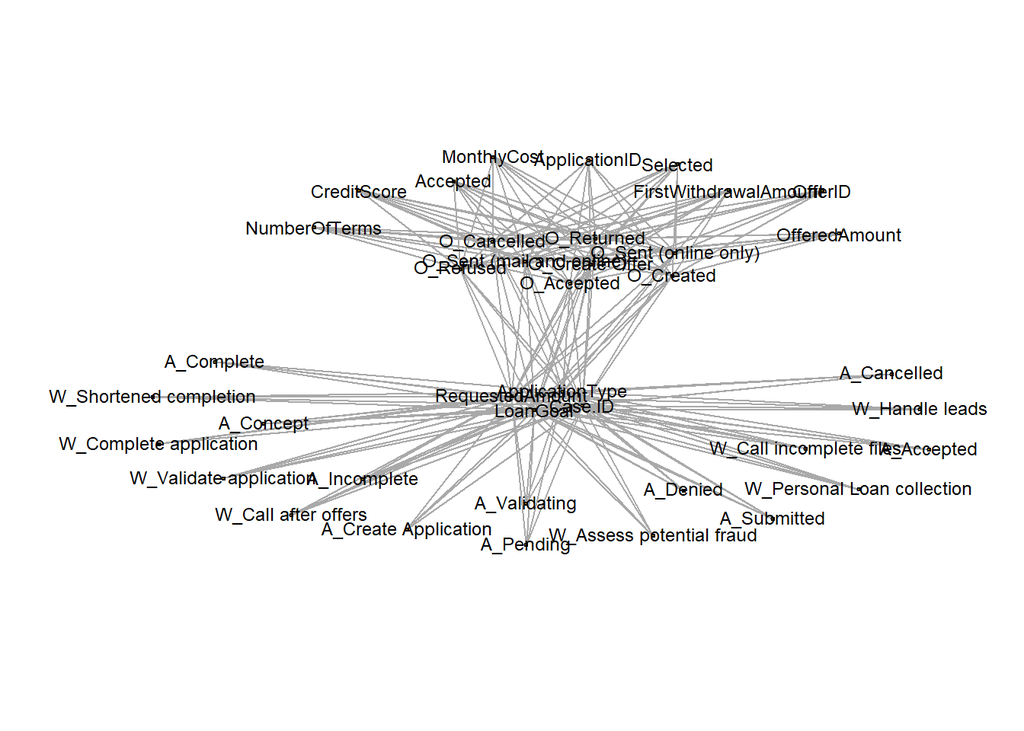

```r
a2aMatrix <- a2a(Offer.union) # put any a2a matrix here to generate a2a diagram (Activity needs to be first column)
a2aMatrix <- column_to_rownames(a2aMatrix, 1) # make activities vertices
g <- graph_from_incidence_matrix(a2aMatrix, multiple = FALSE)

plot(g,
     vertex.label.cex=0.75,
     vertex.label.family="Helvetica",
     vertex.label.font=1,

     vertex.shape="circle",
     vertex.size=1,
     vertex.label.color="black",
     edge.width=1,
     asp = 0.5,
     margin = 0)
```

By forcing the bipartite layout of A2A Diagrams, we can clearly identify related attributes. In this case, the community structure of the A2A Diagram “finds” the same classes as MLAD + FCSE.

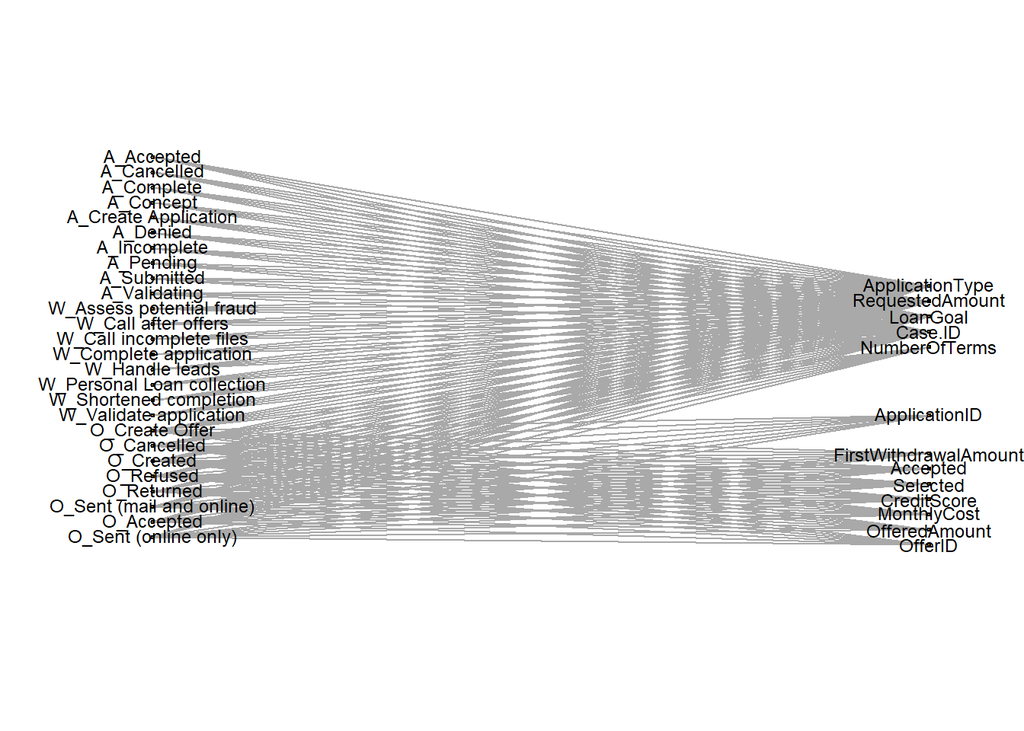

```r
l <- layout.bipartite(g, vgap = 0.1)
plot(g, layout=-l[,2:1],
     vertex.label.cex=0.75,
     vertex.label.family="Helvetica",
     vertex.label.font=1,

     vertex.shape="circle",
     vertex.size=1,
     vertex.label.color="black",
     edge.width=1,
     asp = 0.5,
     margin = 0)
```

Taking the Road Traffic Fine Management (RTFM) dataset from the original paper on discovering data models on single event logs, the community structure also “identifies” the same classes as the base algorithm.

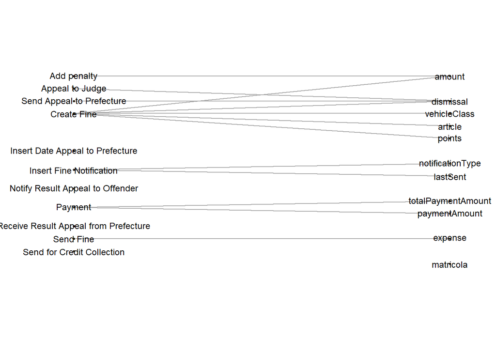

```r
RoadTraffic <- read.csv(here("data", "Road_Traffic_Fine_Management_Process.csv"))
RoadTraffic <- replaceEmptyWithNA(RoadTraffic)
RoadTraffic <- dropSuperfluousAttributes(RoadTraffic)

rt <- a2a(RoadTraffic) #put any a2a matrix here to generate a2a diagram (Activity needs to be first column)
rt <- column_to_rownames(rt, 1) #Remove Activity
g <- graph_from_incidence_matrix(rt, multiple = FALSE)
l <- layout.bipartite(g, vgap = 0.1)
plot(g, layout=-l[,2:1],
     vertex.label.cex=0.75,
     vertex.label.family="Helvetica",
     vertex.label.font=1,

     vertex.shape="circle",
     vertex.size=1,
     vertex.label.color="black",
     edge.width=1,
     asp = 0.5,
     margin = 0)
```